# Bootstrap Estimation for Boston Housing

This example demonstrates how to perform *bootstrap estimation for Simple Linear Regression (SLR)* using the Boston Housing Dataset.

We use the response variable `medv` and the predictor variable `lstat` as an example. We will generate a linear regression model first and then use bootstrap resampling to estimate the sampling variability, bias, and confidence intervals of the intercept and slope.

```r
data <- read.csv("BostonHousing.csv")
source("main.R")

# Example variables
respond <- "medv"
predictor <- "lstat"
```

## Data

The Boston Housing dataset contains housing and neighborhood variables for census tracts in the Boston area (Harrison Jr and Rubinfeld 1978).

### Dataset preview

```r
dim(data)
```

```
#> [1] 506  14
```

```r
names(data)
```

```
#>  [1] "crim"    "zn"      "indus"   "chas"    "nox"     "rm"      "age"
#>  [8] "dis"     "rad"     "tax"     "ptratio" "b"       "lstat"   "medv"
```

```r
head(data, 5)
```

```
#>      crim zn indus chas   nox    rm  age    dis rad tax ptratio      b lstat
#> 1 0.00632 18  2.31    0 0.538 6.575 65.2 4.0900   1 296    15.3 396.90  4.98
#> 2 0.02731  0  7.07    0 0.469 6.421 78.9 4.9671   2 242    17.8 396.90  9.14
#> 3 0.02729  0  7.07    0 0.469 7.185 61.1 4.9671   2 242    17.8 392.83  4.03
#> 4 0.03237  0  2.18    0 0.458 6.998 45.8 6.0622   3 222    18.7 394.63  2.94
#> 5 0.06905  0  2.18    0 0.458 7.147 54.2 6.0622   3 222    18.7 396.90  5.33
#>   medv
#> 1 24.0
#> 2 21.6
#> 3 34.7
#> 4 33.4
#> 5 36.2
```

### Basic summary for the two variables used

```r
summary(data[, c(predictor, respond)])
```

```
#>      lstat            medv
#>  Min.   : 1.73   Min.   : 5.00
#>  1st Qu.: 6.95   1st Qu.:17.02
#>  Median :11.36   Median :21.20
#>  Mean   :12.65   Mean   :22.53
#>  3rd Qu.:16.95   3rd Qu.:25.00
#>  Max.   :37.97   Max.   :50.00
```

### IQR Visualization: Predictor vs Response

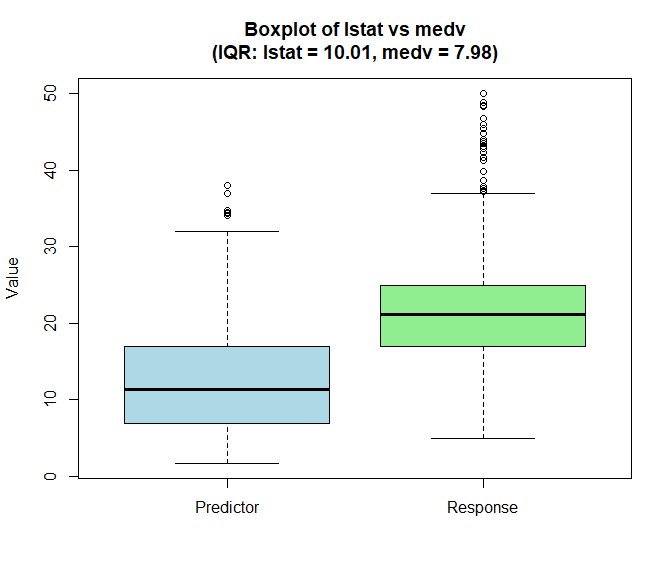

```r
plot_iqr_boxplot(data, predictor, respond)
```

### Scatterplot of response vs predictor

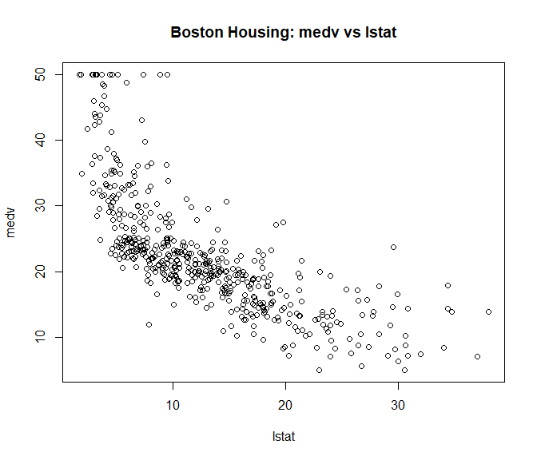

```r
plot(data[[predictor]], data[[respond]],
     xlab = predictor,
     ylab = respond,
     main = "Boston Housing: medv vs lstat")
```

### Correlation (Pearson) and p-value

```r
cor_res <- calculate_correlation(data, predictor, respond)
cor_res
```

```
#> $correlation
#> [1] -0.7376627
#>
#> $p_value
#> [1] 5.081103e-88
```

## Simple Linear Regression

### OLS estimation

```r
ols_slr <- ols_estimators(data, predictor = predictor, respond = respond)
ols_slr
```

```
#> $beta0
#> [1] 34.55384
#>
#> $beta1
#> [1] -0.9500494
#>
#> $ols_conf_int
#>                 2.5 %     97.5 %
#> (Intercept) 33.448457 35.6592247
#> lstat       -1.026148 -0.8739505
```

We use standard diagnostic plots to check:

1. **Linearity**
2. **Independence**
3. **Homoscedasticity**
4. **Normality of residuals**

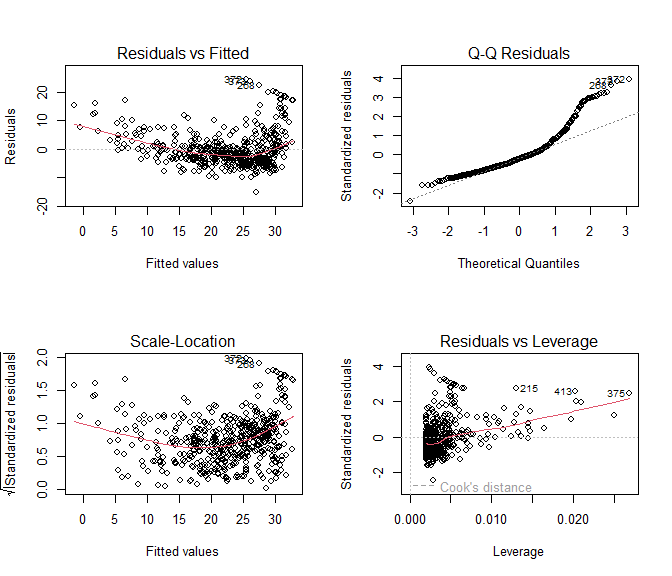

```r
lr_model <- lm(reformulate(predictor, respond), data = data)
par(mfrow = c(2, 2))
plot(lr_model)
```

```r
par(mfrow = c(1, 1))
```

### Residuals vs predictor (extra check)

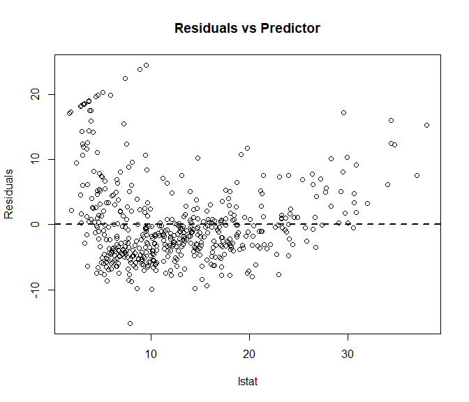

```r
resid_vals <- resid(lr_model)
plot(data[[predictor]], resid_vals,
     xlab = predictor,
     ylab = "Residuals",
     main = "Residuals vs Predictor")
abline(h = 0, lwd = 2, lty = 2)
```

### OLS fitted line on the scatterplot

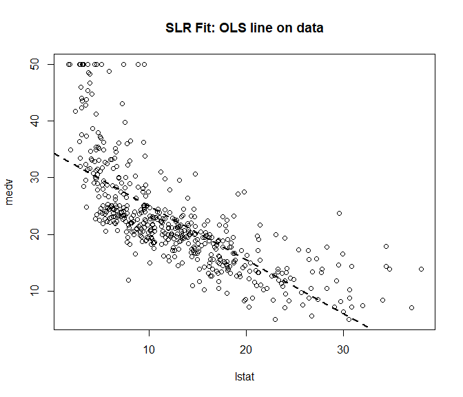

```r
plot(data[[predictor]], data[[respond]],
     xlab = predictor,
     ylab = respond,
     main = "SLR Fit: OLS line on data")
abline(lr_model, lwd = 2, lty = 2)
```

## Bootstrap for Simple Linear Regression

### Bootstrap estimation

We run bootstrap with `R = 1000` resamples.

```r
boot_slr <- bootstrap_slr_summary(
  data = data,
  R = 1000,
  seed = 123,
  predictor = predictor,
  respond = respond
)
names(boot_slr)
```

```
#> [1] "boot_b0_star" "boot_b1_star" "boot_b0_sd"   "boot_b1_sd"   "boot_b0_bias"
#> [6] "boot_b1_bias" "boot_b0_ci"   "boot_b1_ci"
```

### Bootstrap Correlation Distribution: Predictor vs Response

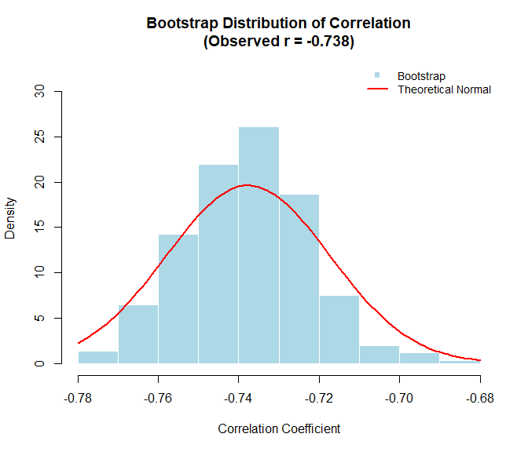

```r
plot_bootstrap_correlation(data, predictor, respond)
```

## Comparative Analysis between Two Models

### Bootstrap summary table (bias / variance / MSE)

```r
boot_table <- bootstrap_slr(boot_slr, ols_slr)
knitr::kable(boot_table, digits = 4)
```

| term | ols | boot_mean | boot_se | bias | variance | mse |
| --- | --- | --- | --- | --- | --- | --- |
| intercept | 34.5538 | 34.5318 | 0.7558 | -0.0221 | 0.5712 | 0.5717 |
| slope | -0.9500 | -0.9497 | 0.0496 | 0.0003 | 0.0025 | 0.0025 |

### Bootstrap histograms with OLS reference

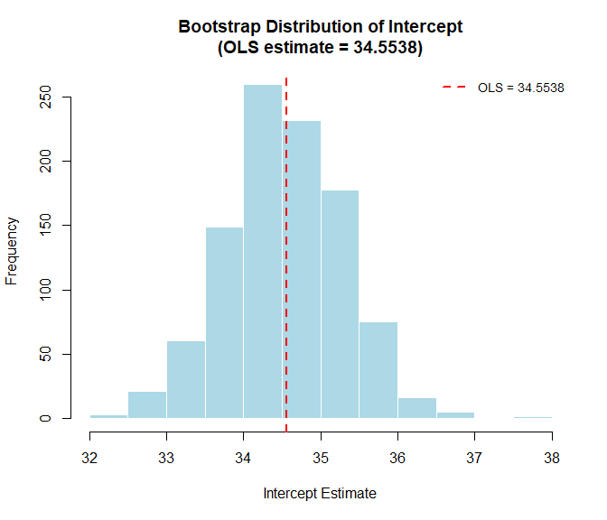

```r
plot_boot_hist(boot_slr, ols_slr, term = "intercept")
```

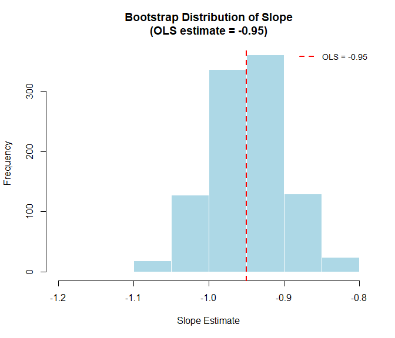

```r
plot_boot_hist(boot_slr, ols_slr, term = "slope")
```

### Confidence interval comparison (Bootstrap percentile vs OLS Wald)

```r
ci_list <- bootstrap_slr_ci(boot_slr, ols_slr, level = 0.95)

ci_list$boot_perc
```

```
#>              lower      upper
#> intercept 33.02327 35.9244346
#> slope     -1.04653 -0.8531665
```

```r
ci_list$ols_wald
```

```
#>               lower      upper
#> intercept 33.448457 35.6592247
#> slope     -1.026148 -0.8739505
```

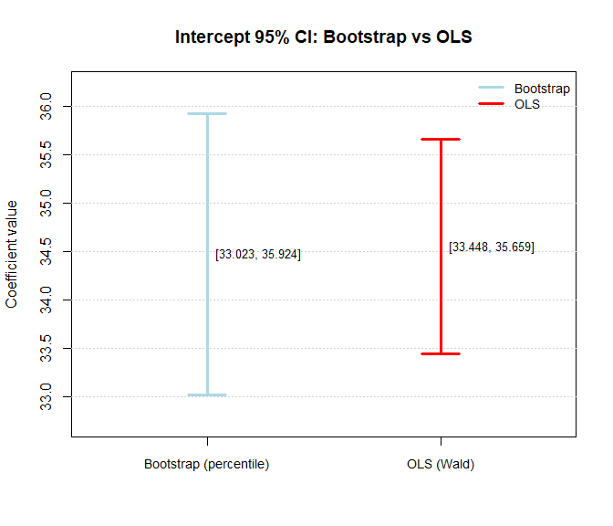

```r
plot_ci_box(ci_list, term = "intercept")
```

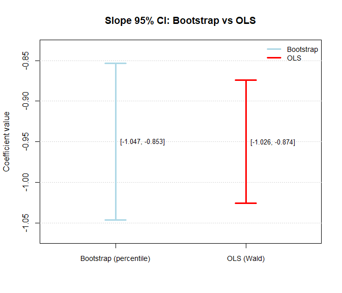

```r
plot_ci_box(ci_list, term = "slope")
```

### Comparison of Bootstrap estimation and OLS estimation

This figure visualizes the joint sampling distribution of the intercept and slope using the Bootstrap method with 1000 resamples. We can identify the following message:

Parameter correlation: The tilt direction of the point cloud shows the trade-off between the intercept and slope.

Model stability: The dispersion of the point cloud corresponds to the variance of the parameter estimates.

Estimation reliability: Whether the orange rhombus falls within a high-density region indicates the representativeness of the original estimate.

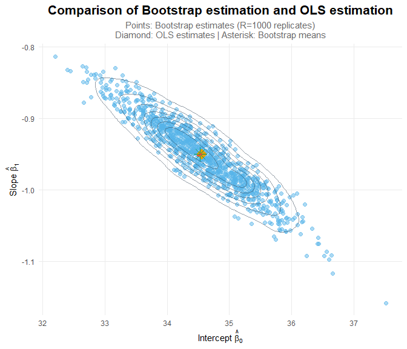

```r
plot_lr_bootstrap_scatter(ols_slr, boot_slr)
```

## AI Statement

In the Vingette.rmd, the Generative AI (ChatGPT) was used to address the data reading issue. It also helped understand how to structure the bootstrap summary section, especially how to organize the comparison between bootstrap percentile CI and OLS Wald CI in the text and plots.

In the Shiny package, no AI tools were used, on the deployment website, or at any stage of writing this tutorial. All contents were developed with reference to and following the structure, logic, and examples provided by the instructor.

In the main.R, AI provide suggestions on how to visualize the comparison of Bootstrap estimation and OLS estimation. The final decision of using the bivariate graph of the joint sample distribution comes from the knowledge in MAT332 and other STA courses.

When debugging the test_bootstrap_boston, prompted to AI with “Why does the R=100 causing error”, the ChatGPT indicates that actually, setting R = 100 itself didn’t trigger the red fatal error. The red crosses we saw on lines 124 and 128 during tests were definitely due to the insetting of the variable R. This helped with locating the error in “main.R”, which setted R = 1000 inside the function, causing R = 100 in the test giving error.

AI also gave suggestions on plotting the IQR and Bootstrap distribution plots for the correlation coefficient, and it provided a clear template approach along with some ideas for writing the code. Those helped a lot with writing our code.

All final choices, variable selections, implementations, interpretations, and visualizations were reviewed and edited by the authors.

## Bibliography

Burns, Patrick. 2011. *The R Inferno*. San Francisco, CA: No Starch Press.

Canty, Angelo, Brian D. Ripley, and Alessandra R. Brazzale. 2025. *Boot: Bootstrap Functions*. https://CRAN.R-project.org/package=boot.

Chang, Winston, Joe Cheng, JJ Allaire, Carson Sievert, Barret Schloerke, Yihui Xie, Jeff Allen, Jonathan McPherson, Alan Dipert, and Barbara Borges. 2025. *Shiny: Web Application Framework for r*. https://CRAN.R-project.org/package=shiny.

Davison, A. C., and D. V. Hinkley. 1997. *Bootstrap Methods and Their Applications*. Cambridge: Cambridge University Press. https://doi.org/10.1017/CBO9780511802843.

Davison, Anthony C., and D. V. Hinkley. 1997. *Bootstrap Methods and Their Application*. Cambridge: Cambridge University Press. https://doi.org/10.1017/CBO9780511802843.

Douglas, Alex, Deon Roos, Francesca Mancini, Ana Couto, and David Lusseau. 2019. *An Introduction to R*. 2nd ed. Boca Raton, FL: CRC Press.

Faraway, Julian J. 2005. *Linear Models with r*. Vol. 63. Texts in Statistical Science Series. Boca Raton, FL: Chapman & Hall/CRC.

Harrison Jr, David, and Daniel L Rubinfeld. 1978. “Hedonic Housing Prices and the Demand for Clean Air.” *Journal of Environmental Economics and Management*.

R Core Team. 2025. *R: A Language and Environment for Statistical Computing*. Vienna, Austria: R Foundation for Statistical Computing. https://www.R-project.org/.

Voss, Jochen. 2013. *An Introduction to Statistical Computing: A Simulation-Based Approach*. John Wiley & Sons.

Wickham, Hadley. 2016. *Ggplot2: Elegant Graphics for Data Analysis*. Springer-Verlag New York. https://ggplot2.tidyverse.org.

———. 2019. *Advanced r*. 2nd ed. Boca Raton: Chapman; Hall/CRC. https://adv-r.hadley.nz/.

———. 2026. *Testthat: Unit Testing for r*. https://cran.r-project.org/package=testthat.

Wickham, Hadley, Peter Danenberg, Gábor Csárdi, et al. 2024. *Roxygen2: In-Line Documentation for r*. https://cran.r-project.org/package=roxygen2.